# Practical Session 2 GD Variants Batch - Mini-Batch - Stochastic Alaa

## Practical Work 2

For this practical work, the student will have to develop a Python program that is able to implement the gradient descent variants (Batch/Mini-Batch/Stochastic) in order to achieve the linear regression of a set of datapoints.

#### Import numpy, matplotlib.pyplot and make it inline

```python
import numpy as np
import matplotlib.pyplot as plt
import pandas as pd
from sklearn.metrics import r2_score
```

To have a dataset or set of data points, the student must generate a pair of arrays **X** and **y** with the values in **X** equally distributed between **0** and **20** and the values in **y** such that: **yi = a*xi + b (and a = -2, b = 1)**

```python
a = np.linspace(0,20)
b =-2*a+1
```

#### Use your code from practical session 1 and create a function to perform GD for single variable linear regression.

#### The function should take the following input parameters:

##### Input data (X), Target Labels (y), Learning Rate (alpha), Maximum number of iterations

#### The function should return the following:

##### All Theta_0 and Theta_1 values till converge, and equivellant Losses, all hypothesis output, and optimum values of Theta_0 and Theta_1

#### Note: you can choose any suitable stop criteria.

```python
dict={'x1':a , 'y':b}
df=pd.DataFrame(dict)
df.head()
```

|  | x1 | y |
| --- | --- | --- |
| 0 | 0.000000 | 1.000000 |
| 1 | 0.408163 | 0.183673 |
| 2 | 0.816327 | -0.632653 |
| 3 | 1.224490 | -1.448980 |
| 4 | 1.632653 | -2.265306 |

```python
alpha = 0.001
itera = 100
theta0=0
theta1=0
```

```python
col=df.shape[1]
a=np.array(df.loc[:,['x1']])
b=np.array(df.loc[:,['y']])
```

```python
a
```

```
array([[ 0.        ],
       [ 0.40816327],
       [ 0.81632653],
       [ 1.2244898 ],
       [ 1.63265306],
       [ 2.04081633],
       [ 2.44897959],
       [ 2.85714286],
       [ 3.26530612],
       [ 3.67346939],
       [ 4.08163265],
       [ 4.48979592],
       [ 4.89795918],
       [ 5.30612245],
       [ 5.71428571],
       [ 6.12244898],
       [ 6.53061224],
       [ 6.93877551],
       [ 7.34693878],
       [ 7.75510204],
       [ 8.16326531],
       [ 8.57142857],
       [ 8.97959184],
       [ 9.3877551 ],
       [ 9.79591837],
       [10.20408163],
       [10.6122449 ],
       [11.02040816],
       [11.42857143],
       [11.83673469],
       [12.24489796],
       [12.65306122],
       [13.06122449],
       [13.46938776],
       [13.87755102],
       [14.28571429],
       [14.69387755],
       [15.10204082],
       [15.51020408],
       [15.91836735],
       [16.32653061],
       [16.73469388],
       [17.14285714],
       [17.55102041],
       [17.95918367],
       [18.36734694],
       [18.7755102 ],
       [19.18367347],
       [19.59183673],
       [20.        ]])
```

```python
b
```

```
array([[  1.        ],
       [  0.18367347],
       [ -0.63265306],
       [ -1.44897959],
       [ -2.26530612],
       [ -3.08163265],
       [ -3.89795918],
       [ -4.71428571],
       [ -5.53061224],
       [ -6.34693878],
       [ -7.16326531],
       [ -7.97959184],
       [ -8.79591837],
       [ -9.6122449 ],
       [-10.42857143],
       [-11.24489796],
       [-12.06122449],
       [-12.87755102],
       [-13.69387755],
       [-14.51020408],
       [-15.32653061],
       [-16.14285714],
       [-16.95918367],
       [-17.7755102 ],
       [-18.59183673],
       [-19.40816327],
       [-20.2244898 ],
       [-21.04081633],
       [-21.85714286],
       [-22.67346939],
       [-23.48979592],
       [-24.30612245],
       [-25.12244898],
       [-25.93877551],
       [-26.75510204],
       [-27.57142857],
       [-28.3877551 ],
       [-29.20408163],
       [-30.02040816],
       [-30.83673469],
       [-31.65306122],
       [-32.46938776],
       [-33.28571429],
       [-34.10204082],
       [-34.91836735],
       [-35.73469388],
       [-36.55102041],
       [-37.36734694],
       [-38.18367347],
       [-39.        ]])
```

```python
noBatch=10
```

```python
def batch(x,y,alpha,epochs):
    theta_0=[]
    theta_1=[]
    ress=[]
    noBatch=10
    theta0=0
    theta1=0
    hyp=[]


    for i in range(epochs):
        h=theta0+theta1*x
        hyp.append(h)
        error = sum((h-y)**2)
        res = error/ (2 * len(x))
        ress.append(res)
        a = sum(h-y) / ( len(x))
        b = sum((h-y)*x) / ( len(x))
        theta0 = theta0 - alpha*a
        theta_0.append(theta0)
        theta1 = theta1 - alpha*b
        theta_1.append(theta1)
    dict1={"theta_0":theta0,"theta_1":theta1,"losses":ress,"hypothesis output":hyp,"optimum theta_0":theta_0,"optimum theta_1":theta_1}
    return dict1
```

```python
dict2 = batch(a,b,0.001,100)
```

```python
dict2
```

[output not shown]

[output cut: 297 more lines]

[output not shown]

#### Try your function with any input parameterss of your choice.

#### Calculate r2 score

```python
r2_score(b, dict2["hypothesis output"][-1] )
```

```
0.9976972946618887
```

```python
loss=np.array(dict2['losses'])
```

#### Plot loss vs. epochs

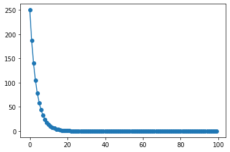

```python
loss=np.array(dict2['losses'])
plt.plot(loss,'-o')
```

```python
len(loss)
```

```
100
```

#### Plot Theta_0 vs. loss and Theta_1 vs. loss

```python
Theta_0=np.array(dict2['optimum theta_0'])
```

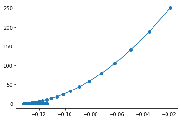

```python
plt.plot(Theta_0,loss,'-o')
```

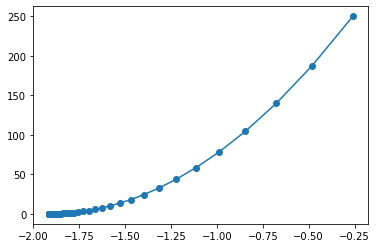

```python
plt.plot(dict2['optimum theta_1'],loss,'-o')
```

#### Plot all regression lines till converge

```python
hypo_mini=np.array(dict2['hypothesis output'])
```

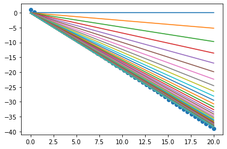

```python
plt.scatter(a,b)
for i in range(100) :
    plt.plot(a,dict2['hypothesis output'][i])
```

### Note: Try once without shuffling the data and once with shuffle and see the effect on the output.

```python
#without shuffling

a = np.linspace(0,20).reshape(50,1)
b =-2*a+1
```

```python
def mini_batch(x,y,alpha,epochs):
    theta_0=[]
    theta_1=[]
    ress=[]
    theta0=0
    theta1=0
    hyp=[]
    b=10

    for i in range(epochs):
        for j in range(int(len(x)/b)):
            h=theta0+theta1*x[j:j+b]

            error = sum((h-y[j:j+b])**2)
            res = error/ (2 * b)
            ress.append(res)
            a = sum(h-y[j:j+b]) / b
            p = sum((h-y[j:j+b])*x[j:j+b]) / b
            theta0 = theta0 - alpha*a
            theta_0.append(theta0)
            theta1 = theta1 - alpha*p
            theta_1.append(theta1)
        h=theta0+theta1*x
        hyp.append(h)
    dict1={"theta_0":theta0,"theta_1":theta1,"losses":ress,"hypothesis output":hyp,"optimum theta_0":theta_0,"optimum theta_1":theta_1}
    return dict1
```

```python
dict3 = mini_batch(a,b,0.001,100)
```

```python
r2_score(b, dict3["hypothesis output"][-1] )
```

```
0.9978922298320467
```

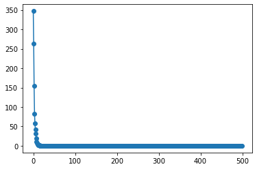

```python
plt.plot(dict3['losses'],'-o')
```

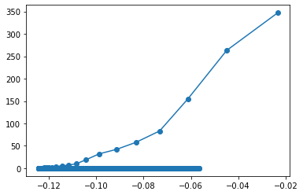

```python
plt.plot(dict3['optimum theta_0'],dict3['losses'],'-o')
```

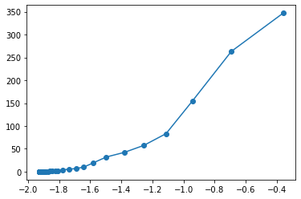

```python
plt.plot(dict3['optimum theta_1'],dict3['losses'],'-o')
```

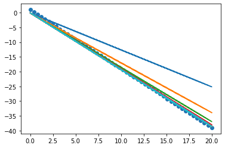

```python
plt.scatter(a,b)
for i in range(100) :
    plt.plot(a,dict3['hypothesis output'][i])
```

```python
#with shuffling

a = np.linspace(0,20).reshape(50,1)
np.random.shuffle(a)
b =-2*a+1
```

```python
dict4 = mini_batch(a,b,0.001,100)
```

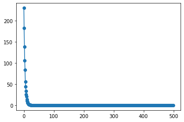

```python
plt.plot(dict4['losses'],'-o')
```

```python
r2_score(b, dict4["hypothesis output"][-1] )
```

```
0.9978835119751718
```

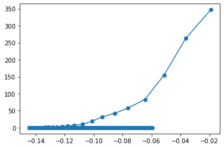

```python
plt.plot(dict4['optimum theta_0'],dict3['losses'],'-o')
```

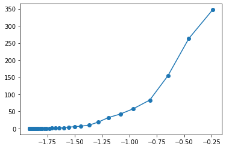

```python
plt.plot(dict4['optimum theta_1'],dict3['losses'],'-o')
```

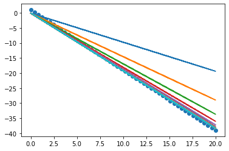

```python
plt.scatter(a,b)
for i in range(100) :
    plt.plot(a,dict4['hypothesis output'][i])
```

## Stochastic GD

#### Update the implementation of the Batch GD to beStochastic and rpeat the above plots and evaluations

#### You can try different learning rate and see its effect.

#### Compare to Batch and Mini-Batch GD

### Note: Try once without shuffling the data and once with shuffle and see the effect on the output.

```python
def stochastic(x,y,alpha,epochs):
    theta_0=[]
    theta_1=[]
    ress=[]
    theta0=0
    theta1=0
    hyp=[]
    b=1


    for i in range(epochs):
        for j in range(int(len(x)/b)):
            h=theta0+theta1*x[j:j+b]

            error = sum((h-y[j:j+b])**2)
            res = error/ (2 * b)
            ress.append(res)
            a = sum(h-y[j:j+b]) / b
            p = sum((h-y[j:j+b])*x[j:j+b]) / b
            theta0 = theta0 - alpha*a
            theta_0.append(theta0)
            theta1 = theta1 - alpha*p
            theta_1.append(theta1)
        h=theta0+theta1*x
        hyp.append(h)
    dict1={"theta_0":theta0,"theta_1":theta1,"losses":ress,"hypothesis output":hyp,"optimum theta_0":theta_0,"optimum theta_1":theta_1}
    return dict1
```

```python
#without shuffling

a = np.linspace(0,20).reshape(50,1)
b =-2*a+1
```

```python
dict5 = stochastic(a,b,0.0001,50)
```

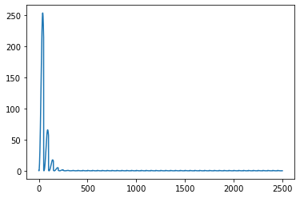

```python
plt.plot(dict5['losses'])
```

```python
r2_score(b, dict5["hypothesis output"][-1] )
```

```
0.9978037526037133
```

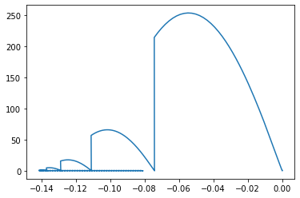

```python
plt.plot(dict5['optimum theta_0'],dict5['losses'])
```

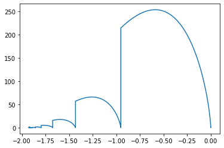

```python
plt.plot(dict5['optimum theta_1'],dict5['losses'])
```

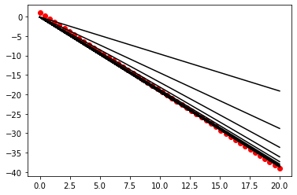

```python
plt.scatter(a,b,c="r")
for i in range(50) :
    plt.plot(a,dict5['hypothesis output'][i],c="black")
```

```python
#with shuffling

a = np.linspace(0,20).reshape(50,1)
np.random.shuffle(a)
b =-2*a+1
```

```python
dict6 = stochastic(a,b,0.0001,50)
```

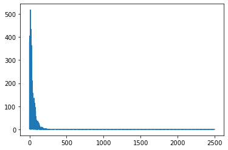

```python
plt.plot(dict6['losses'])
```

```python
r2_score(b, dict6["hypothesis output"][-1] )
```

```
0.9978695188516333
```

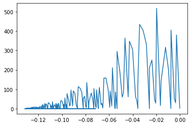

```python
plt.plot(dict6['optimum theta_0'],dict6['losses'])
```

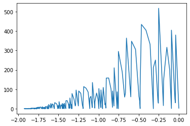

```python
plt.plot(dict6['optimum theta_1'],dict6['losses'])
```

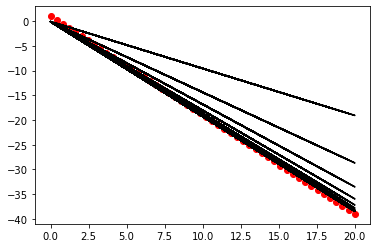

```python
plt.scatter(a,b,c="r")
for i in range(50) :
    plt.plot(a,dict6['hypothesis output'][i],c="black")
```